# Biostat 203B Homework 2

Due Feb 6 @ 11:59PM

YANLONG BAI

```r
knitr::opts_chunk$set(echo = TRUE, cache = TRUE, cache.lazy = FALSE)
library(R.utils)
library(tidyverse)
library(data.table)
library(lubridate)
library(dummies)
```

```r
os <- sessionInfo()$running
if (str_detect(os, "Linux")) {
  mimic_path <- "/mnt/mimiciv/1.0"
} else if (str_detect(os, "macOS")) {
  mimic_path <- "/Users/huazhou/Documents/Box Sync/MIMIC/mimic-iv-1.0"
}
```

In this exercise, we use tidyverse (ggpot2, dplyr, etc) to explore the [MIMIC-IV](https://mimic.mit.edu/docs/iv/) data introduced in [homework 1](https://ucla-biostat-203b.github.io/2022winter/hw/hw1/hw1.html) and to build a cohort of ICU stays.

```r
# tree -s -L 2 /Users/huazhou/Documents/Box\ Sync/MIMIC/mimic-iv-1.0
system(str_c("tree -s -L 2 ", shQuote(mimic_path)), intern = TRUE)
```

## Q1. `read.csv` (base R) vs `read_csv` (tidyverse) vs `fread` (data.table)

There are quite a few utilities in R for reading plain text data files. Let us test the speed of reading a moderate sized compressed csv file, `admissions.csv.gz`, by three programs: `read.csv` in base R, `read_csv` in tidyverse, and `fread` in the popular data.table package.

Which function is fastest? Is there difference in the (default) parsed data types? (Hint: R function `system.time` measures run times.)

**Solution**

```r
if (Sys.info()[["nodename"]] == "biostat-203b-teaching-server") {
  system.time(read.csv("/mnt/mimiciv/1.0/core/admissions.csv.gz"))
} else {
  system.time(
    read.csv("/Users/a123456/Desktop/203B/1.0/core/admissions.csv.gz"))

}
```

```
##    user  system elapsed
##  10.887   0.186  11.095
```

```r
if (Sys.info()[["nodename"]] == "biostat-203b-teaching-server") {
  system.time(read_csv("/mnt/mimiciv/1.0/core/admissions.csv.gz",
                       show_col_types = FALSE))
} else {
system.time(read_csv("/Users/a123456/Desktop/203B/1.0/core/admissions.csv.gz",
                     show_col_types = FALSE))
}
```

```
##    user  system elapsed
##   0.772   0.380   0.687
```

```r
if (Sys.info()[["nodename"]] == "biostat-203b-teaching-server") {
  system.time(fread("/mnt/mimiciv/1.0/core/admissions.csv.gz"))
} else {
system.time(fread("/Users/a123456/Desktop/203B/1.0/core/admissions.csv.gz"))
}
```

```
##    user  system elapsed
##   0.837   0.337   1.179
```

For later questions, we stick to the tidyverse.

## Q2. ICU stays

`icustays.csv.gz` (https://mimic.mit.edu/docs/iv/modules/icu/icustays/) contains data about Intensive Care Units (ICU) stays. The first 10 lines are

```r
system(
  str_c(
    "zcat < ",
    shQuote(str_c(mimic_path, "/icu/icustays.csv.gz")),
    " | head"
    ),
  intern = TRUE
)
```

1. Import `icustatys.csv.gz` as a tibble `icustays_tble`.

**Solution**

```r
if (Sys.info()[["nodename"]] == "biostat-203b-teaching-server") {
  icustays_tble = read_csv("/mnt/mimiciv/1.0/icu/icustays.csv.gz",
                           show_col_types = FALSE)
} else {
icustays_tble = read_csv("/Users/a123456/Desktop/203B/1.0/icu/icustays.csv.gz",
                         show_col_types = FALSE)
}

icustays_tble
```

```
## # A tibble: 76,540 × 8
##    subject_id  hadm_id  stay_id first_careunit last_careunit intime
##         <dbl>    <dbl>    <dbl> <chr>          <chr>         <dttm>
##  1   17867402 24528534 31793211 Trauma SICU (… Trauma SICU … 2154-03-03 04:11:00
##  2   14435996 28960964 31983544 Trauma SICU (… Trauma SICU … 2150-06-19 17:57:00
##  3   17609946 27385897 33183475 Trauma SICU (… Trauma SICU … 2138-02-05 18:54:00
##  4   18966770 23483021 34131444 Trauma SICU (… Trauma SICU … 2123-10-25 10:35:00
##  5   12776735 20817525 34547665 Neuro Stepdown Neuro Stepdo… 2200-07-12 00:33:00
##  6   10215159 24283593 34569476 Trauma SICU (… Trauma SICU … 2124-09-20 15:05:29
##  7   14489052 26516390 35056286 Trauma SICU (… Trauma SICU … 2118-10-26 10:33:56
##  8   15914763 28906020 36909804 Trauma SICU (… Trauma SICU … 2176-12-14 12:00:00
##  9   16256226 20013290 39289362 Neuro Stepdown Neuro Stepdo… 2150-12-20 16:09:08
## 10   19194449 21641999 39387567 Coronary Care… Coronary Car… 2123-11-12 02:53:35
## # … with 76,530 more rows, and 2 more variables: outtime <dttm>, los <dbl>
```

2. How many unique `subject_id`? Can a `subject_id` have multiple ICU stays?

**Solution**

```r
distinct(icustays_tble, subject_id, .keep_all = TRUE) %>%
  summarise(n = n())
```

```
## # A tibble: 1 × 1
##       n
##   <int>
## 1 53150
```

The result indicates that there are only 53150 unique `subject_id`s, which is much less than the total number (76540). So there must be some `subject_id`s having multiple ICU stays.

3. For each `subject_id`, let’s only keep the first ICU stay in the tibble `icustays_tble`.

**Solution**

```r
icustays_tble = icustays_tble %>%
  group_by(subject_id) %>%
  arrange(intime, .by_group = TRUE) %>%
  slice_head(n = 1) %>%
  ungroup()
icustays_tble
```

```
## # A tibble: 53,150 × 8
##    subject_id  hadm_id  stay_id first_careunit last_careunit intime
##         <dbl>    <dbl>    <dbl> <chr>          <chr>         <dttm>
##  1   10000032 29079034 39553978 Medical Inten… Medical Inte… 2180-07-23 14:00:00
##  2   10000980 26913865 39765666 Medical Inten… Medical Inte… 2189-06-27 08:42:00
##  3   10001217 24597018 37067082 Surgical Inte… Surgical Int… 2157-11-20 19:18:02
##  4   10001725 25563031 31205490 Medical/Surgi… Medical/Surg… 2110-04-11 15:52:22
##  5   10001884 26184834 37510196 Medical Inten… Medical Inte… 2131-01-11 04:20:05
##  6   10002013 23581541 39060235 Cardiac Vascu… Cardiac Vasc… 2160-05-18 10:00:53
##  7   10002155 23822395 33685454 Coronary Care… Coronary Car… 2129-08-04 12:45:00
##  8   10002223 22494570 39638202 Trauma SICU (… Trauma SICU … 2158-01-15 08:01:49
##  9   10002348 22725460 32610785 Neuro Interme… Neuro Interm… 2112-11-30 23:24:00
## 10   10002428 28662225 33987268 Medical Inten… Medical Inte… 2156-04-12 16:24:18
## # … with 53,140 more rows, and 2 more variables: outtime <dttm>, los <dbl>
```

## Q3. `admission` data

Information of the patients admitted into hospital is available in `admissions.csv.gz`. See https://mimic.mit.edu/docs/iv/modules/core/admissions/ for details of each field in this file. The first 10 lines are

```r
system(
  str_c(
    "zcat < ",
    shQuote(str_c(mimic_path, "/core/admissions.csv.gz")),
    " | head"
    ),
  intern = TRUE
)
```

1. Import `admissions.csv.gz` as a tibble `admissions_tble`.

**Solution**

```r
if (Sys.info()[["nodename"]] == "biostat-203b-teaching-server") {
  admissions_tble =
    read_csv("/mnt/mimiciv/1.0/core/admissions.csv.gz",
             show_col_types = FALSE)
} else {
admissions_tble =
  read_csv("/Users/a123456/Desktop/203B/1.0/core/admissions.csv.gz",
           show_col_types = FALSE)
}

admissions_tble
```

```
## # A tibble: 523,740 × 15
##    subject_id  hadm_id admittime           dischtime
##         <dbl>    <dbl> <dttm>              <dttm>
##  1   14679932 21038362 2139-09-26 14:16:00 2139-09-28 11:30:00
##  2   15585972 24941086 2123-10-07 23:56:00 2123-10-12 11:22:00
##  3   11989120 21965160 2147-01-14 09:00:00 2147-01-17 14:25:00
##  4   17817079 24709883 2165-12-27 17:33:00 2165-12-31 21:18:00
##  5   15078341 23272159 2122-08-28 08:48:00 2122-08-30 12:32:00
##  6   19124609 20517215 2169-03-14 12:44:00 2169-03-20 19:15:00
##  7   17301855 29732723 2140-06-06 14:23:00 2140-06-08 14:25:00
##  8   17991012 24298836 2181-07-10 20:28:00 2181-07-12 15:49:00
##  9   16865435 23216961 2185-07-19 02:12:00 2185-07-21 11:50:00
## 10   13693648 21640725 2111-01-30 23:43:00 2111-02-02 13:03:00
## # … with 523,730 more rows, and 11 more variables: deathtime <dttm>,
## #   admission_type <chr>, admission_location <chr>, discharge_location <chr>,
## #   insurance <chr>, language <chr>, marital_status <chr>, ethnicity <chr>,
## #   edregtime <dttm>, edouttime <dttm>, hospital_expire_flag <dbl>
```

2. Let’s only keep the admissions that have a match in `icustays_tble` according to `subject_id` and `hadmi_id`.

**Solution**

```r
admissions_tble = admissions_tble %>%
  semi_join(select(icustays_tble, subject_id, hadm_id),
            by = c("subject_id", "hadm_id"))
admissions_tble
```

```
## # A tibble: 53,150 × 15
##    subject_id  hadm_id admittime           dischtime
##         <dbl>    <dbl> <dttm>              <dttm>
##  1   10222255 28200985 2120-11-20 20:25:00 2120-11-22 13:00:00
##  2   14485852 28712010 2113-10-31 00:23:00 2113-11-04 16:50:00
##  3   18709254 23758948 2195-10-12 01:31:00 2195-10-12 13:51:00
##  4   16837807 23526268 2151-03-19 06:09:00 2151-03-19 07:20:00
##  5   17642680 27734285 2116-05-29 12:48:00 2116-05-30 12:31:00
##  6   18230965 21251728 2142-03-12 20:00:00 2142-03-17 15:26:00
##  7   17374121 27667114 2115-07-22 07:15:00 2115-07-24 17:50:00
##  8   13346506 28533404 2181-11-19 14:32:00 2181-11-22 18:47:00
##  9   18030332 24679656 2152-07-22 21:28:00 2152-07-27 16:49:00
## 10   14328744 29576470 2126-08-20 09:26:00 2126-08-21 11:36:00
## # … with 53,140 more rows, and 11 more variables: deathtime <dttm>,
## #   admission_type <chr>, admission_location <chr>, discharge_location <chr>,
## #   insurance <chr>, language <chr>, marital_status <chr>, ethnicity <chr>,
## #   edregtime <dttm>, edouttime <dttm>, hospital_expire_flag <dbl>
```

3. Summarize the following variables by graphics.
- admission year
- admission month
- admission month day
- admission week day
- admission hour (anything unusual?)

**Solution**

RMK: for the following images, I use the `admissions_tble` instead of the `admissions_tble_filtered`, so if the images have little difference with your answer, this is the reason!!!

For “admission year”:

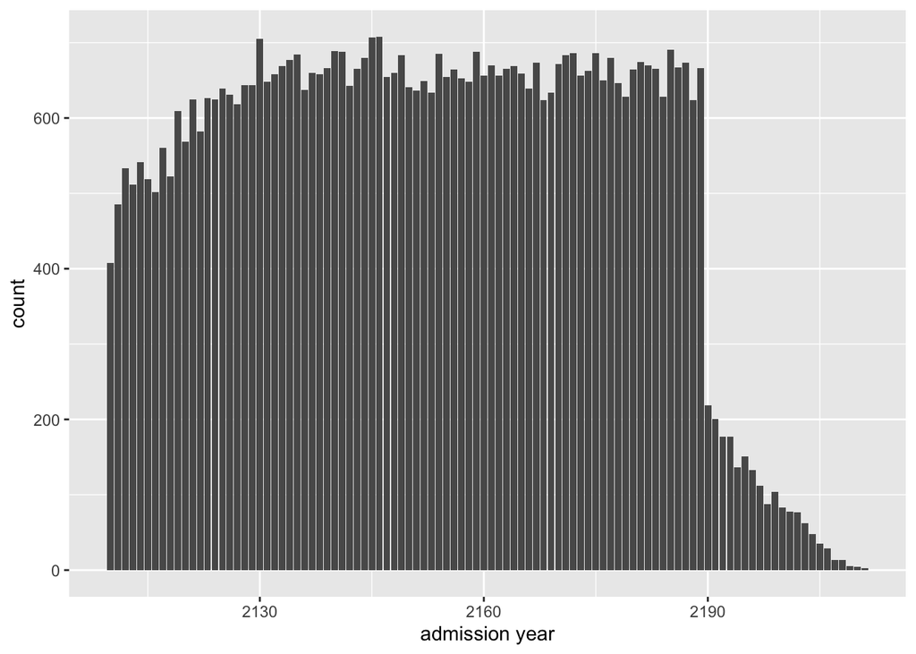

```r
admissions_tble %>%
  ggplot() +
  geom_bar(mapping = aes(x = year(admittime))) +
  labs(x = "admission year")
```

For “admission month”:

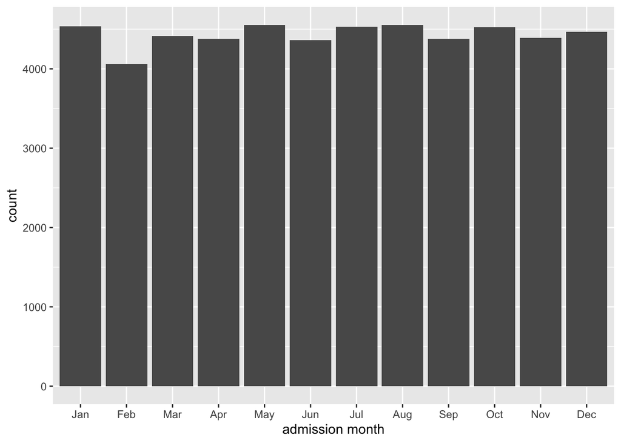

```r
admissions_tble %>%
  ggplot() +
  geom_bar(mapping = aes(x = lubridate::month(admittime, label = TRUE))) +
  labs(x = "admission month")
```

For “admission month day”:

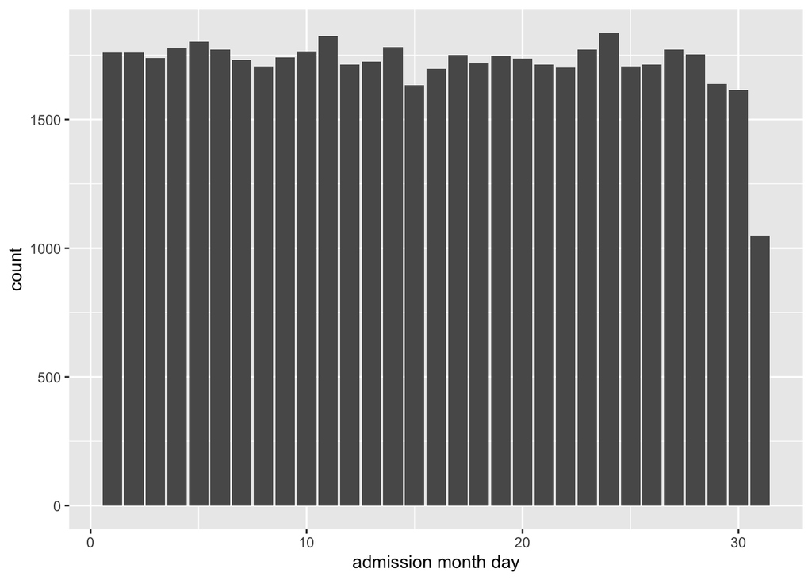

```r
admissions_tble %>%
  ggplot() +
  geom_bar(mapping = aes(x = mday(admittime))) +
  labs(x = "admission month day")
```

For “admission week day”:

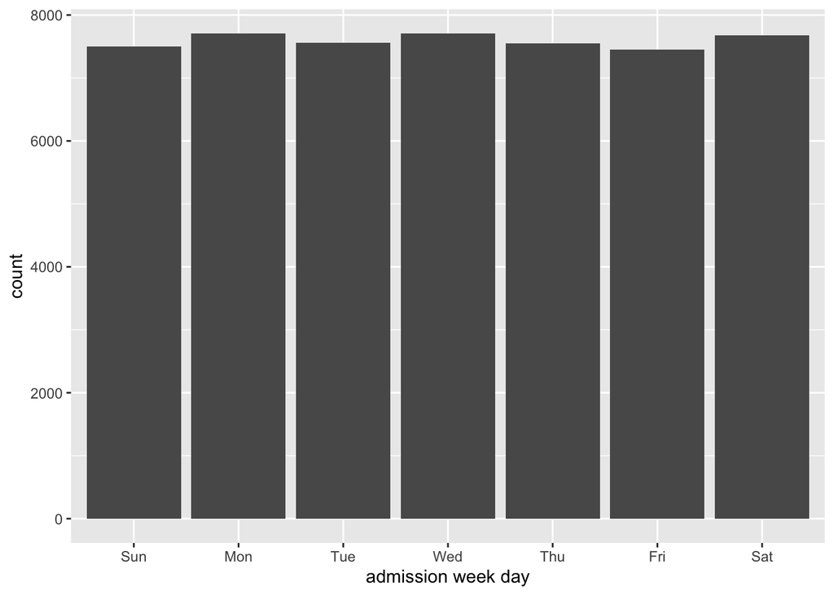

```r
admissions_tble %>%
  ggplot() +
  geom_bar(mapping =
             aes(x = lubridate::wday(admittime, label = TRUE, abbr = TRUE))) +
  labs(x = "admission week day")
```

For “admission hour”:

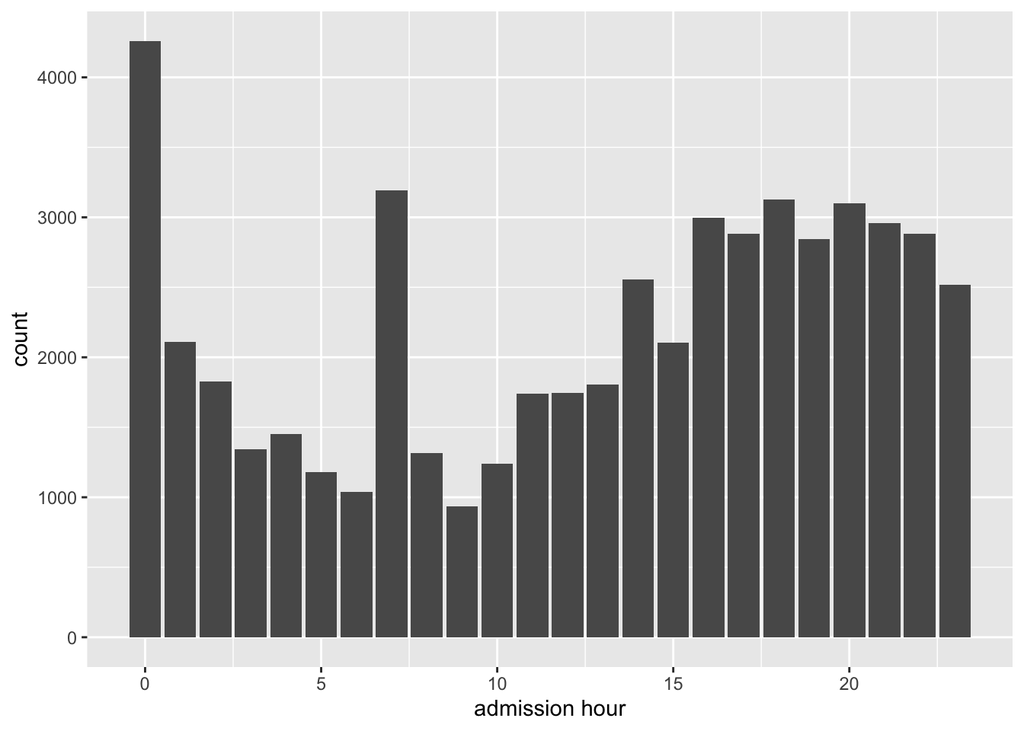

```r
admissions_tble %>%
  ggplot() +
  geom_bar(mapping = aes(x = hour(admittime))) +
  labs(x = "admission hour")
```

## Q4. `patients` data

Patient information is available in `patients.csv.gz`. See https://mimic.mit.edu/docs/iv/modules/core/patients/ for details of each field in this file. The first 10 lines are

```r
system(
  str_c(
    "zcat < ",
    shQuote(str_c(mimic_path, "/core/patients.csv.gz")),
    " | head"
    ),
  intern = TRUE
)
```

1. Import `patients.csv.gz` (https://mimic.mit.edu/docs/iv/modules/core/patients/) as a tibble `patients_tble` and only keep the patients who have a match in `icustays_tble` (according to `subject_id`).

**Solution**

```r
if (Sys.info()[["nodename"]] == "biostat-203b-teaching-server") {
patients_tble =
  read_csv("/mnt/mimiciv/1.0/core/patients.csv.gz") %>%
  inner_join(select(icustays_tble, subject_id), by = "subject_id")
} else {
patients_tble =
  read_csv("/Users/a123456/Desktop/203B/1.0/core/patients.csv.gz") %>%
  inner_join(select(icustays_tble, subject_id), by = "subject_id")
}
patients_tble
```

```
## # A tibble: 53,150 × 6
##    subject_id gender anchor_age anchor_year anchor_year_group dod
##         <dbl> <chr>       <dbl>       <dbl> <chr>             <date>
##  1   10018928 F              31        2125 2008 - 2010       NA
##  2   10076543 F              78        2187 2008 - 2010       NA
##  3   10098428 F              85        2119 2008 - 2010       NA
##  4   10127185 M              60        2141 2008 - 2010       NA
##  5   10148710 M              67        2137 2008 - 2010       NA
##  6   10156486 F              75        2124 2017 - 2019       NA
##  7   10159585 M              59        2146 2008 - 2010       2154-04-16
##  8   10171525 F              27        2115 2014 - 2016       NA
##  9   10196360 M              57        2118 2011 - 2013       NA
## 10   10227823 M              45        2156 2014 - 2016       NA
## # … with 53,140 more rows
```

2. Summarize variables `gender` and `anchor_age`, and explain any patterns you see.

**Solution**

```r
summary(as.factor(patients_tble[[2]]))
```

```
##     F     M
## 23353 29797
```

```r
# the total number of observations of two sexes.
summary(patients_tble[[3]])
```

```
##    Min. 1st Qu.  Median    Mean 3rd Qu.    Max.
##   18.00   53.00   65.00   63.51   77.00   91.00
```

```r
# the overall summary statistics of "anchor_age".
patients_tble %>%
group_by(gender) %>%
  summarise(mean(anchor_age, na.rm = TRUE))
```

```
## # A tibble: 2 × 2
##   gender `mean(anchor_age, na.rm = TRUE)`
##   <chr>                             <dbl>
## 1 F                                  64.8
## 2 M                                  62.5
```

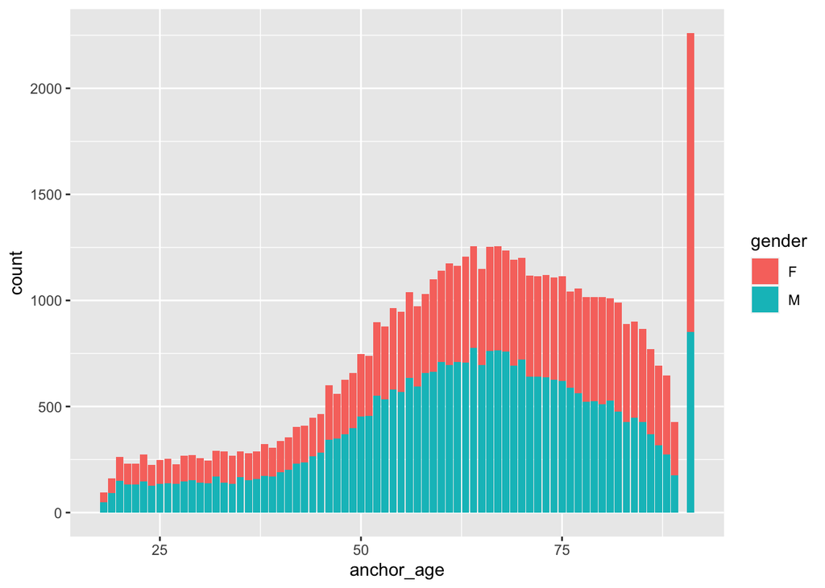

```r
# the mean value of "anchor_age" of each gender.
ggplot(data = patients_tble) +
  geom_bar(mapping = aes(x = anchor_age, fill = gender))
```

```r
dum = dummy(patients_tble$gender)
t.test(dum[,2], patients_tble$anchor_age)
```

```
##
##  Welch Two Sample t-test
##
## data:  dum[, 2] and patients_tble$anchor_age
## t = -840.86, df = 53237, p-value < 2.2e-16
## alternative hypothesis: true difference in means is not equal to 0
## 95 percent confidence interval:
##  -63.09961 -62.80613
## sample estimates:
##  mean of x  mean of y
##  0.5606209 63.5134901
```

```r
rm(dum)
gc()
```

```
##           used (Mb) gc trigger  (Mb) limit (Mb) max used  (Mb)
## Ncells 1436560 76.8    4059040 216.8         NA  3528644 188.5
## Vcells 8846851 67.5   25766360 196.6      32768 37026019 282.5
```

## Q5. Lab results

`labevents.csv.gz` (https://mimic.mit.edu/docs/iv/modules/hosp/labevents/) contains all laboratory measurements for patients. The first 10 lines are

```r
system(
  str_c(
    "zcat < ",
    shQuote(str_c(mimic_path, "/hosp/labevents.csv.gz")),
    " | head"
    ),
  intern = TRUE
)
```

`d_labitems.csv.gz` is the dictionary of lab measurements.

```r
system(
  str_c(
    "zcat < ",
    shQuote(str_c(mimic_path, "/hosp/d_labitems.csv.gz")),
    " | head"
    ),
  intern = TRUE
)
```

1. Find how many rows are in `labevents.csv.gz`.

**Solution**

Local:

```bash
gzip -cd "/Users/a123456/Desktop/203B/1.0/hosp/labevents.csv.gz" | wc -l
```

```
##  122103668
```

Online server:

```bash
gzip -cd "/mnt/mimiciv/1.0/hosp/labevents.csv.gz" | wc -l
```

[output not shown]

2. We are interested in the lab measurements of creatinine (50912), potassium (50971), sodium (50983), chloride (50902), bicarbonate (50882), hematocrit (51221), white blood cell count (51301), glucose (50931), magnesium (50960), and calcium (50893). Retrieve a subset of `labevents.csv.gz` only containing these items for the patients in `icustays_tble` as a tibble `labevents_tble`.

   Hint: `labevents.csv.gz` is a data file too big to be read in by the `read_csv` function in its default setting. Utilize the `col_select` and `lazy` options in the `read_csv` function to reduce the memory burden.

**Solution**

```r
interest_lab_mes =
  c(50912, 50971, 50983, 50902, 50882, 51221, 51301, 50931, 50960, 50893)

if (Sys.info()[["nodename"]] == "biostat-203b-teaching-server") {
  lab_mes =
  read_csv("/mnt/mimiciv/1.0/hosp/d_labitems.csv.gz",
           col_select = c(1,2), show_col_types = FALSE) %>%
  filter(itemid %in% interest_lab_mes)
labevents_tble =
  read_csv(
    "/mnt/mimiciv/1.0/hosp/labevents_filtered_itemid.csv.gz",
    show_col_types = FALSE) %>%
  inner_join(lab_mes, by = "itemid") %>%
  inner_join(select(icustays_tble, subject_id), by = "subject_id")
} else {
lab_mes =
  read_csv("/Users/a123456/Desktop/203B/1.0/hosp/d_labitems.csv.gz",
           col_select = c(1,2), show_col_types = FALSE) %>%
  filter(itemid %in% interest_lab_mes)
labevents_tble =
  read_csv(
    "/Users/a123456/Desktop/203B/1.0/hosp/labevents_filtered_itemid.csv.gz",
    show_col_types = FALSE) %>%
  inner_join(lab_mes, by = "itemid") %>%
  inner_join(select(icustays_tble, subject_id), by = "subject_id")
}

labevents_tble
```

```
## # A tibble: 16,698,462 × 5
##    subject_id itemid charttime           valuenum label
##         <dbl>  <dbl> <dttm>                 <dbl> <chr>
##  1   10003700  50882 2162-11-15 17:00:00     27   Bicarbonate
##  2   10003700  50902 2162-11-15 17:00:00    103   Chloride
##  3   10003700  50912 2162-11-15 17:00:00      1   Creatinine
##  4   10003700  50931 2162-11-15 17:00:00     93   Glucose
##  5   10003700  50971 2162-11-15 17:00:00      4.1 Potassium
##  6   10003700  50983 2162-11-15 17:00:00    141   Sodium
##  7   10003700  51221 2162-11-15 17:00:00     40   Hematocrit
##  8   10003700  51301 2162-11-15 17:00:00      6.7 White Blood Cells
##  9   10003700  51221 2165-04-24 03:40:00     41   Hematocrit
## 10   10003700  51301 2165-04-24 03:40:00      5.8 White Blood Cells
## # … with 16,698,452 more rows
```

3. Further restrict `labevents_tble` to the first lab measurement during the ICU stay.

**Solution**

```r
labevents_tble =
  left_join(labevents_tble, select(icustays_tble, subject_id, intime, outtime),
            by = "subject_id") %>%
  filter(charttime < outtime &
         charttime > intime
         ) %>%
  group_by(subject_id, itemid) %>%
  arrange(charttime, .by_group = TRUE) %>%
  slice_head(n = 1) %>%
  ungroup() %>%
  select(-intime, -outtime)
labevents_tble1 = labevents_tble
labevents_tble =
  pivot_wider(labevents_tble, names_from = c("itemid", "label"),
              values_from = c("charttime","valuenum"))
labevents_tble
```

```
## # A tibble: 51,619 × 21
##    subject_id charttime_50882_Bicar… `charttime_50893_Calc… charttime_50902_Chl…
##         <dbl> <dttm>                 <dttm>                 <dttm>
##  1   10000032 2180-07-23 21:45:00    2180-07-23 21:45:00    2180-07-23 21:45:00
##  2   10001217 2157-11-21 03:16:00    2157-11-21 03:16:00    2157-11-21 03:16:00
##  3   10001725 2110-04-11 18:02:00    2110-04-11 18:02:00    2110-04-11 18:02:00
##  4   10001884 2131-01-11 06:31:00    2131-01-11 06:31:00    2131-01-11 06:31:00
##  5   10002013 2160-05-18 14:38:00    NA                     2160-05-18 14:38:00
##  6   10002155 2129-08-04 17:56:00    2129-08-04 17:56:00    2129-08-04 17:56:00
##  7   10002223 2158-01-16 01:50:00    2158-01-16 01:50:00    2158-01-16 01:50:00
##  8   10002348 2112-12-01 06:36:00    2112-12-01 06:36:00    2112-12-01 06:36:00
##  9   10002428 2156-04-12 19:24:00    2156-04-12 19:24:00    2156-04-12 19:24:00
## 10   10002430 2129-06-13 00:48:00    2129-06-13 00:48:00    2129-06-13 00:48:00
## # … with 51,609 more rows, and 17 more variables:
## #   charttime_50912_Creatinine <dttm>, charttime_50931_Glucose <dttm>,
## #   charttime_50960_Magnesium <dttm>, charttime_50971_Potassium <dttm>,
## #   charttime_50983_Sodium <dttm>, charttime_51221_Hematocrit <dttm>,
## #   charttime_51301_White Blood Cells <dttm>, valuenum_50882_Bicarbonate <dbl>,
## #   valuenum_50893_Calcium, Total <dbl>, valuenum_50902_Chloride <dbl>,
## #   valuenum_50912_Creatinine <dbl>, valuenum_50931_Glucose <dbl>, …
```

```r
rm(lab_mes)
rm(interest_lab_mes)
gc()
```

```
##           used (Mb) gc trigger   (Mb) limit (Mb)  max used   (Mb)
## Ncells 1196663 64.0    3753897  200.5         NA   4692371  250.6
## Vcells 7293045 55.7  260101205 1984.5      32768 295375355 2253.6
```

4. Summarize the lab measurements by appropriate numerics and graphics.

**Solution**

```r
labevents_tble1 %>%
  group_by(itemid) %>%
      summarise(mean(valuenum, na.rm = TRUE))# the mean values of "valuenum" of different "itemid".
```

```
## # A tibble: 10 × 2
##    itemid `mean(valuenum, na.rm = TRUE)`
##     <dbl>                          <dbl>
##  1  50882                          23.0
##  2  50893                           8.35
##  3  50902                         105.
##  4  50912                           1.31
##  5  50931                         141.
##  6  50960                           2.00
##  7  50971                           4.18
##  8  50983                         138.
##  9  51221                          32.7
## 10  51301                          12.1
```

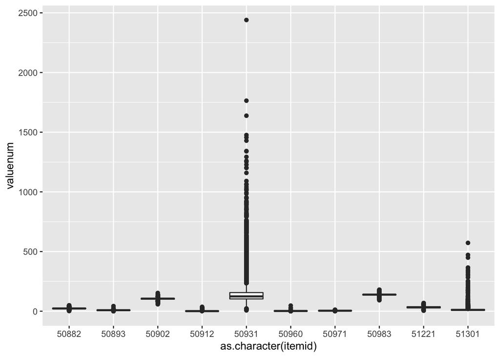

```r
labevents_tble1 %>%
  ggplot() +
  geom_boxplot(mapping = aes(x = as.character(itemid), y = valuenum)) # the boxplot of "valuenum" of different "itemid".
```

## Q6. Vitals from charted events

`chartevents.csv.gz` (https://mimic.mit.edu/docs/iv/modules/icu/chartevents/) contains all the charted data available for a patient. During their ICU stay, the primary repository of a patient’s information is their electronic chart. The `itemid` variable indicates a single measurement type in the database. The `value` variable is the value measured for `itemid`. The first 10 lines of `chartevents.csv.gz` are

```r
system(
  str_c(
    "zcat < ",
    shQuote(str_c(mimic_path, "/icu/chartevents.csv.gz")),
    " | head"),
  intern = TRUE
)
```

`d_items.csv.gz` (https://mimic.mit.edu/docs/iv/modules/icu/d_items/) is the dictionary for the `itemid` in `chartevents.csv.gz`.

```r
system(
  str_c(
    "zcat < ",
    shQuote(str_c(mimic_path, "/icu/d_items.csv.gz")),
    " | head"),
  intern = TRUE
)
```

1. We are interested in the vitals for ICU patients: heart rate (220045), mean non-invasive blood pressure (220181), systolic non-invasive blood pressure (220179), body temperature in Fahrenheit (223761), and respiratory rate (220210). Retrieve a subset of `chartevents.csv.gz` only containing these items for the patients in `icustays_tble` as a tibble `chartevents_tble`.

**Solution**

```r
interest_vit = c(220045, 220181, 220179, 223761, 220210)

if (Sys.info()[["nodename"]] == "biostat-203b-teaching-server") {
  vit =
  read_csv(
    "/mnt/mimiciv/1.0/icu/d_items.csv.gz",
    col_select = c(1),
    show_col_types = FALSE) %>%
  filter(itemid %in% interest_vit)
chartevents_tble =
  read_csv(
    "/mnt/mimiciv/1.0/icu/chartevents_filtered_itemid.csv.gz",
    show_col_types = FALSE) %>%
  inner_join(select(vit, itemid), by = "itemid") %>%
  inner_join(select(icustays_tble, subject_id), by = "subject_id")
} else {
vit =
  read_csv(
    "/Users/a123456/Desktop/203B/1.0/icu/d_items.csv.gz",
    col_select = c(1),
    show_col_types = FALSE) %>%
  filter(itemid %in% interest_vit)
chartevents_tble =
  read_csv(
    "/Users/a123456/Desktop/203B/1.0/icu/chartevents_filtered_itemid.csv.gz",
    show_col_types = FALSE) %>%
  inner_join(select(vit, itemid), by = "itemid") %>%
  inner_join(select(icustays_tble, subject_id), by = "subject_id")
}


chartevents_tble
```

```
## # A tibble: 23,679,058 × 6
##    subject_id  hadm_id  stay_id charttime           itemid valuenum
##         <dbl>    <dbl>    <dbl> <dttm>               <dbl>    <dbl>
##  1   10003700 28623837 30600691 2165-04-24 05:28:00 220179    152
##  2   10003700 28623837 30600691 2165-04-24 05:28:00 220181    110
##  3   10003700 28623837 30600691 2165-04-24 05:30:00 220045     65
##  4   10003700 28623837 30600691 2165-04-24 05:30:00 220210     14
##  5   10003700 28623837 30600691 2165-04-24 05:38:00 223761     97.6
##  6   10003700 28623837 30600691 2165-04-24 06:00:00 220045     56
##  7   10003700 28623837 30600691 2165-04-24 06:00:00 220179    126
##  8   10003700 28623837 30600691 2165-04-24 06:00:00 220181     88
##  9   10003700 28623837 30600691 2165-04-24 06:00:00 220210     14
## 10   10003700 28623837 30600691 2165-04-24 06:09:00 220045     55
## # … with 23,679,048 more rows
```

```r
rm(vit)
rm(interest_vit)
gc()
```

```
##            used  (Mb) gc trigger   (Mb) limit (Mb)  max used   (Mb)
## Ncells  1364663  72.9    3753897  200.5         NA   4692371  250.6
## Vcells 54957226 419.3  208080964 1587.6      32768 295375355 2253.6
```

2. Further restrict `chartevents_tble` to the first vital measurement during the ICU stay.

**Solution**

```r
chartevents_tble =
  left_join(
    chartevents_tble, select(icustays_tble, subject_id, intime, outtime),
    by = "subject_id") %>%
  filter(charttime < outtime &
         charttime > intime
         ) %>%
  group_by(subject_id, itemid) %>%
  arrange(charttime, .by_group = TRUE) %>%
  slice_head(n = 1) %>%
  ungroup() %>%
  select(-intime, -outtime, -hadm_id, -stay_id)
chartevents_tble1 = chartevents_tble
chartevents_tble =
  pivot_wider(
    chartevents_tble, names_prefix = "", names_from = c("itemid"),
    values_from = c("charttime","valuenum"))
chartevents_tble
```

```
## # A tibble: 53,136 × 11
##    subject_id charttime_220045    charttime_220179    charttime_220181
##         <dbl> <dttm>              <dttm>              <dttm>
##  1   10000032 2180-07-23 14:12:00 2180-07-23 14:11:00 2180-07-23 14:11:00
##  2   10000980 2189-06-27 08:56:00 2189-06-27 08:55:00 2189-06-27 08:55:00
##  3   10001217 2157-11-20 19:19:00 2157-11-20 19:19:00 2157-11-20 19:19:00
##  4   10001725 2110-04-11 15:54:00 2110-04-11 16:00:00 2110-04-11 16:00:00
##  5   10001884 2131-01-11 04:22:00 2131-01-11 04:25:00 2131-01-11 04:25:00
##  6   10002013 2160-05-18 14:07:00 2160-05-19 07:53:00 2160-05-19 07:53:00
##  7   10002155 2129-08-04 13:45:00 2129-08-04 16:49:00 2129-08-04 16:49:00
##  8   10002223 2158-01-15 08:15:00 2158-01-15 08:18:00 2158-01-15 08:18:00
##  9   10002348 2112-11-30 23:43:00 2112-12-01 00:10:00 2112-12-01 00:10:00
## 10   10002428 2156-04-12 17:26:00 2156-04-12 17:27:00 2156-04-12 17:27:00
## # … with 53,126 more rows, and 7 more variables: charttime_220210 <dttm>,
## #   charttime_223761 <dttm>, valuenum_220045 <dbl>, valuenum_220179 <dbl>,
## #   valuenum_220181 <dbl>, valuenum_220210 <dbl>, valuenum_223761 <dbl>
```

3. Summarize these vital measurements by appropriate numerics and graphics.

**Solution**

```r
chartevents_tble1 %>%
  group_by(itemid) %>%
      summarise(mean(valuenum, na.rm = TRUE))
```

```
## # A tibble: 5 × 2
##   itemid `mean(valuenum, na.rm = TRUE)`
##    <dbl>                          <dbl>
## 1 220045                           87.4
## 2 220179                          124.
## 3 220181                           87.4
## 4 220210                           18.7
## 5 223761                           98.0
```

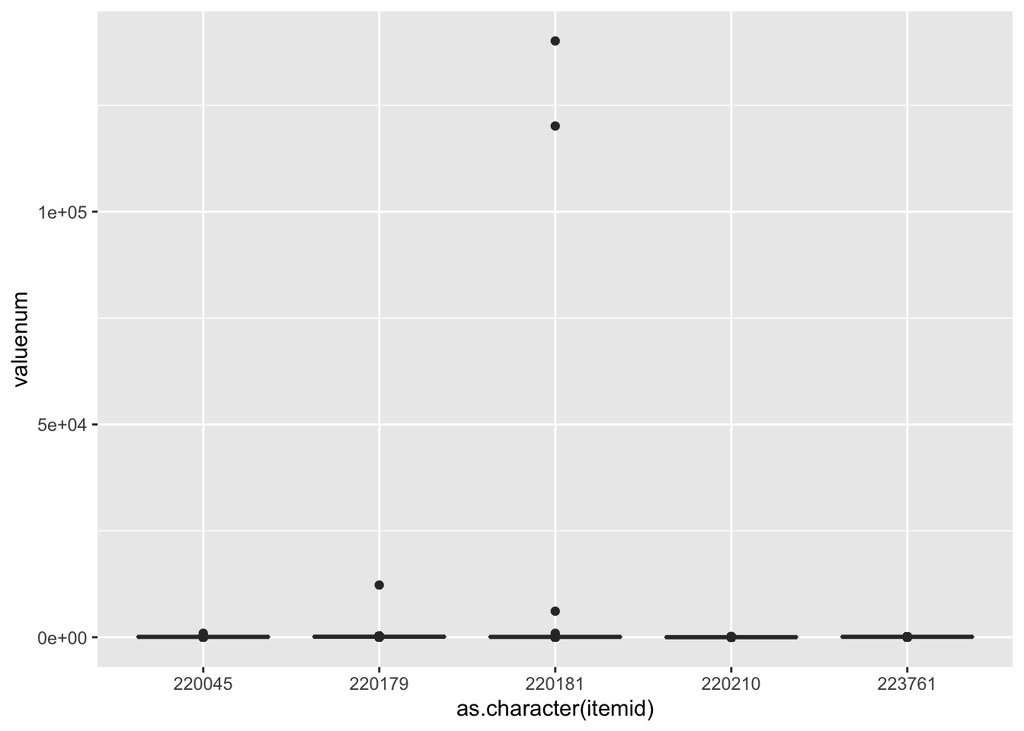

```r
# the mean values of "valuenum" of different "itemid".
chartevents_tble1 %>%
  ggplot() +
  geom_boxplot(mapping = aes(x = as.character(itemid), y = valuenum))
```

```r
# the boxplot of "valuenum" of different "itemid".
```

## Q7. Putting things together

Let us create a tibble `mimic_icu_cohort` for all ICU stays, where rows are

- first ICU stay of each unique adult (age at admission > 18)

and columns contain at least following variables

- all variables in `icustays.csv.gz`
- all variables in `admission.csv.gz`
- all variables in `patients.csv.gz`
- first lab measurements during ICU stay
- first vital measurements during ICU stay
- an indicator variable `thirty_day_mort` whether the patient died within 30 days of hospital admission (30 day mortality)

**Solution**

```r
mimic_icu_cohort =
  left_join(icustays_tble, admissions_tble,
            by = c("subject_id", "hadm_id")) %>%
  left_join(patients_tble, by = "subject_id") %>%
  left_join(labevents_tble, by = "subject_id") %>%
  left_join(chartevents_tble, by = "subject_id") %>%
  mutate(age_hadm = anchor_age + year(admittime) - anchor_year) %>%
  filter(age_hadm > 18) %>%
  mutate(hadm_to_death =
           ifelse(is.na(deathtime), Inf, deathtime - admittime)) %>%
  mutate(thirty_day_mort = hadm_to_death <= 2592000) %>%
  print(width = Inf) %>%
  write_rds("mimic_icu_cohort.rds")
```

```
## # A tibble: 53,065 × 59
##    subject_id  hadm_id  stay_id first_careunit
##         <dbl>    <dbl>    <dbl> <chr>
##  1   10000032 29079034 39553978 Medical Intensive Care Unit (MICU)
##  2   10000980 26913865 39765666 Medical Intensive Care Unit (MICU)
##  3   10001217 24597018 37067082 Surgical Intensive Care Unit (SICU)
##  4   10001725 25563031 31205490 Medical/Surgical Intensive Care Unit (MICU/SICU)
##  5   10001884 26184834 37510196 Medical Intensive Care Unit (MICU)
##  6   10002013 23581541 39060235 Cardiac Vascular Intensive Care Unit (CVICU)
##  7   10002155 23822395 33685454 Coronary Care Unit (CCU)
##  8   10002223 22494570 39638202 Trauma SICU (TSICU)
##  9   10002348 22725460 32610785 Neuro Intermediate
## 10   10002428 28662225 33987268 Medical Intensive Care Unit (MICU)
##    last_careunit                                    intime
##    <chr>                                            <dttm>
```

[output cut: 215 more lines]

## Q8. Exploratory data analysis (EDA)

Summarize following information using appropriate numerics or graphs.

**Solution**

- `thirty_day_mort` vs demographic variables (ethnicity, language, insurance, marital_status, gender, age at hospital admission)

`thirty_day_mort` vs `ethnicity`

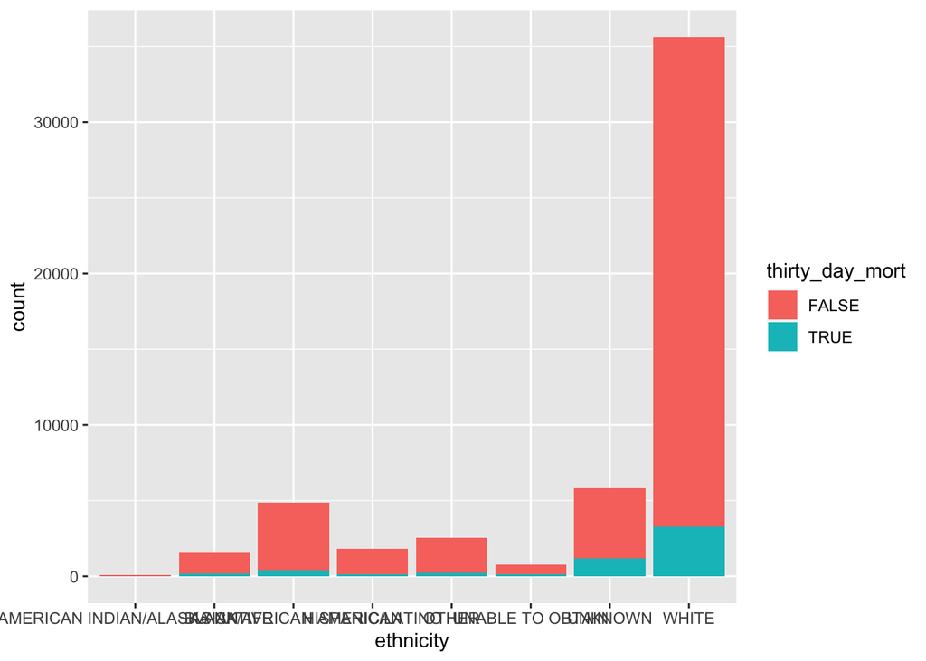

```r
ggplot(data = mimic_icu_cohort) +
  geom_bar(mapping = aes(x = ethnicity, fill = thirty_day_mort))
```

`thirty_day_mort` vs `language`

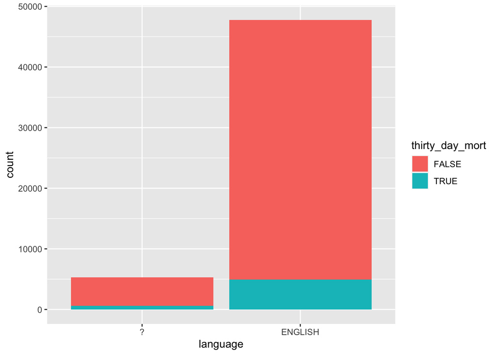

```r
ggplot(data = mimic_icu_cohort) +
  geom_bar(mapping = aes(x = language, fill = thirty_day_mort))
```

`thirty_day_mort` vs `insurance`

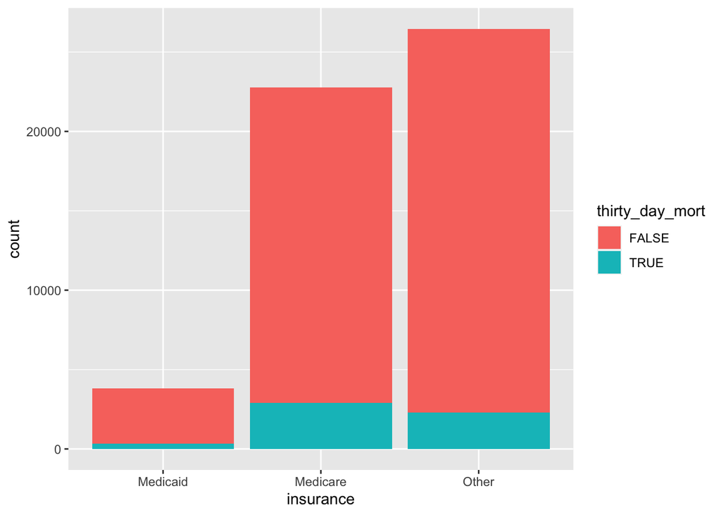

```r
ggplot(data = mimic_icu_cohort) +
  geom_bar(mapping = aes(x = insurance, fill = thirty_day_mort))
```

`thirty_day_mort` vs `marital_status`

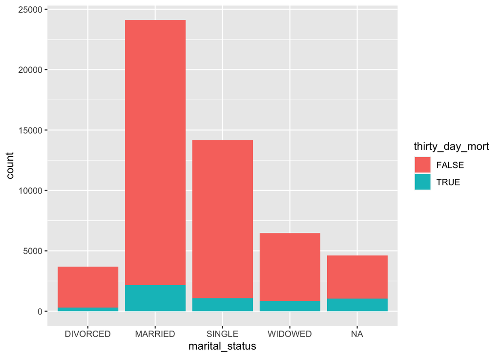

```r
ggplot(data = mimic_icu_cohort) +
  geom_bar(mapping = aes(x = marital_status, fill = thirty_day_mort))
```

`thirty_day_mort` vs `gender`

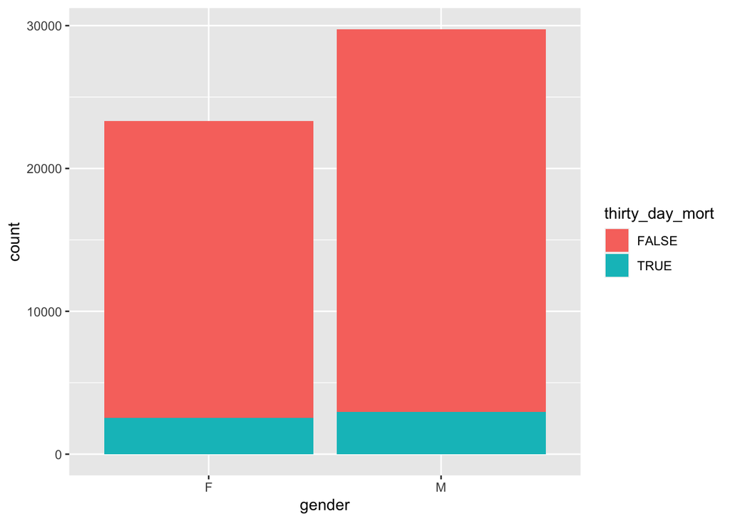

```r
ggplot(data = mimic_icu_cohort) +
  geom_bar(mapping = aes(x = gender, fill = thirty_day_mort))
```

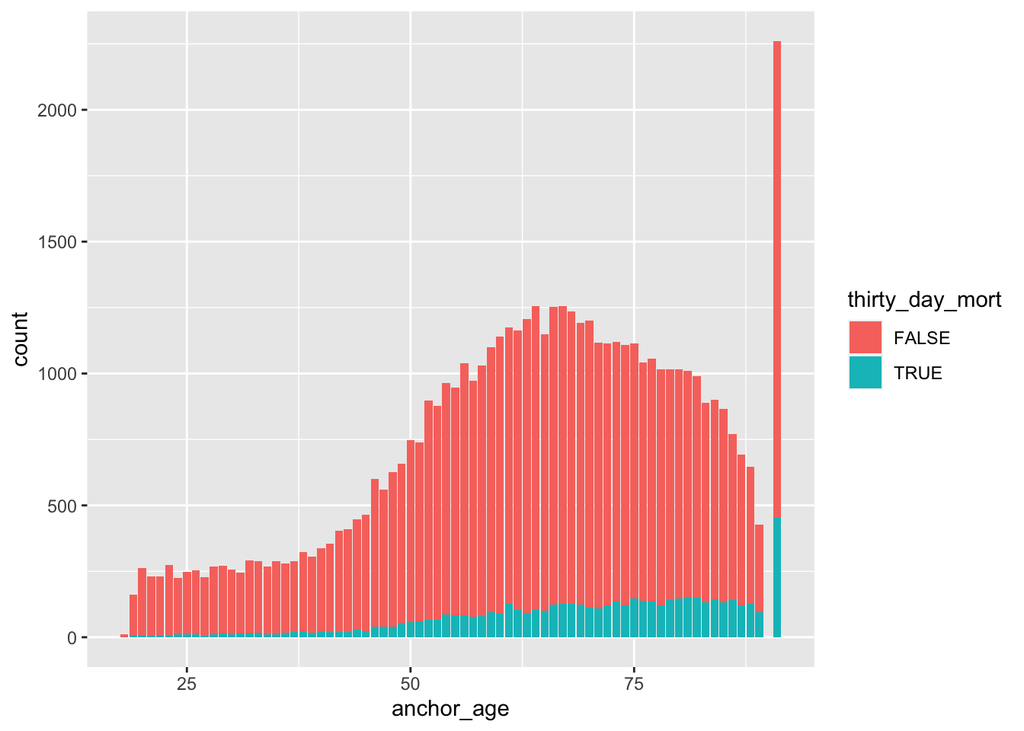

```r
ggplot(data = mimic_icu_cohort) +
  geom_bar(mapping = aes(x = anchor_age, fill = thirty_day_mort))
```

- `thirty_day_mort` vs first lab measurements

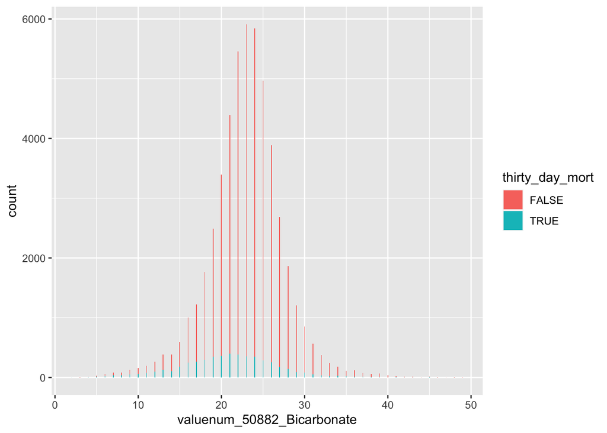

```r
ggplot(data = mimic_icu_cohort) +
  geom_bar(
    mapping = aes(x = valuenum_50882_Bicarbonate, fill = thirty_day_mort))
```

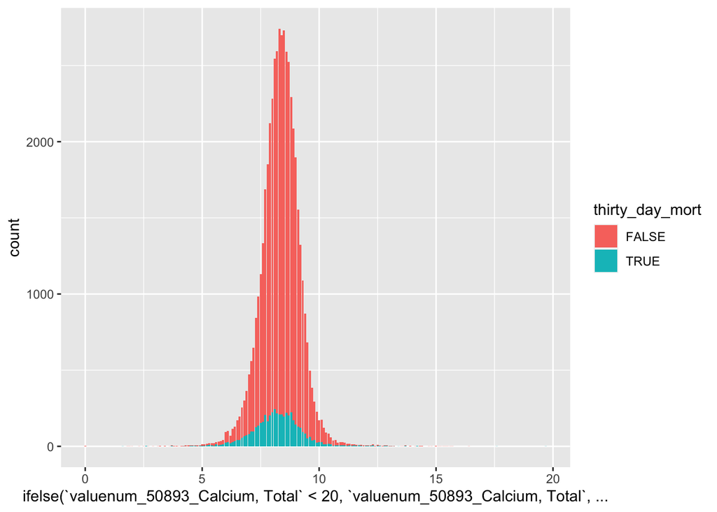

```r
ggplot(data = mimic_icu_cohort) +
  geom_bar(
    mapping = aes(
      x = ifelse(`valuenum_50893_Calcium, Total` < 20,
                 `valuenum_50893_Calcium, Total`, NA),
      fill = thirty_day_mort))
```

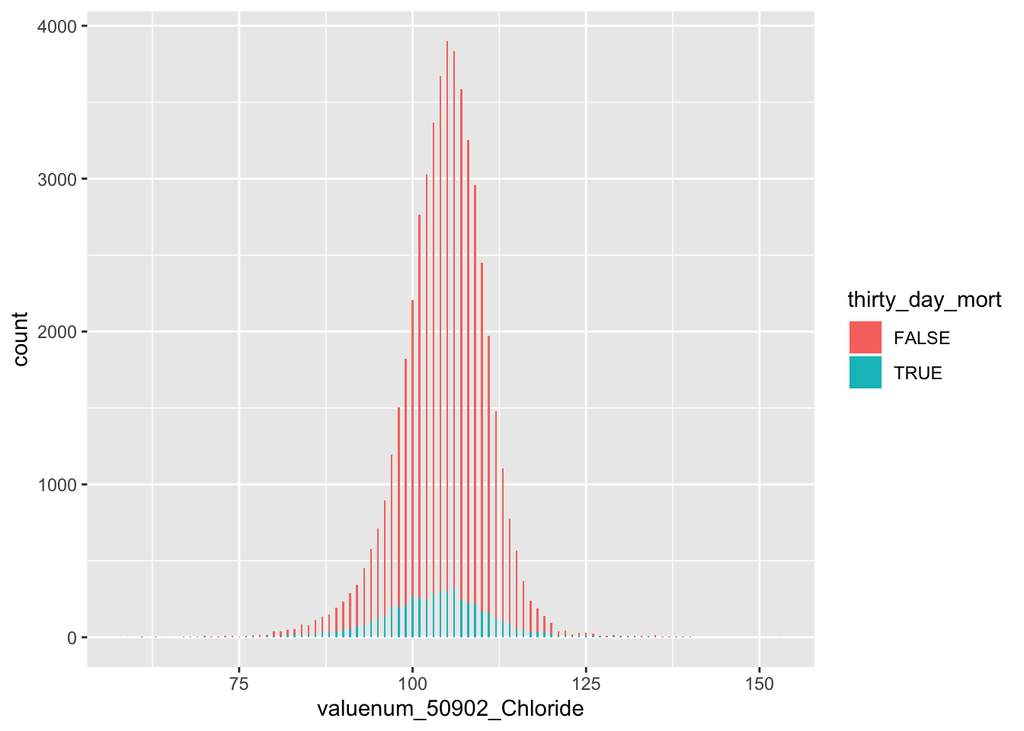

```r
ggplot(data = mimic_icu_cohort) +
  geom_bar(
    mapping = aes(x = valuenum_50902_Chloride, fill = thirty_day_mort))
```

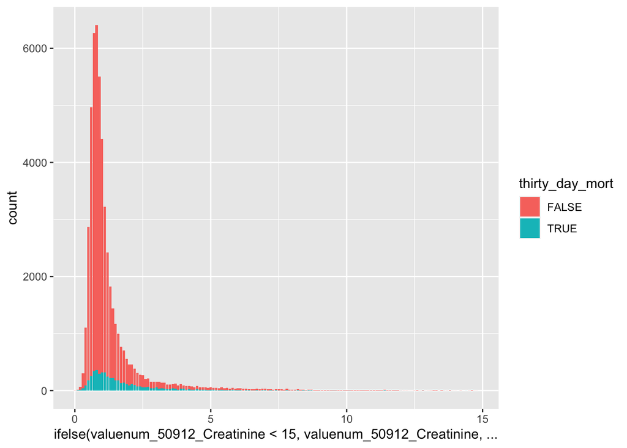

```r
ggplot(data = mimic_icu_cohort) +
  geom_bar(
    mapping = aes(
      x = ifelse(valuenum_50912_Creatinine < 15,
                 valuenum_50912_Creatinine, NA),
      fill = thirty_day_mort))
```

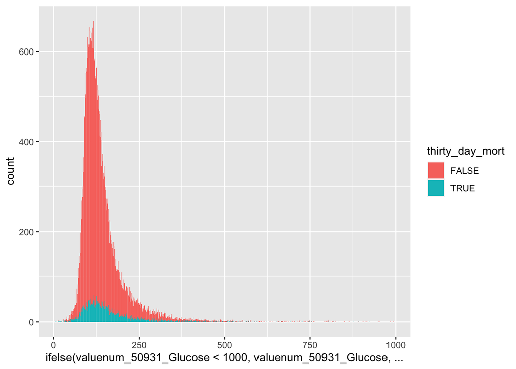

```r
ggplot(data = mimic_icu_cohort) +
  geom_bar(
    mapping = aes(
      x = ifelse(valuenum_50931_Glucose < 1000,
                 valuenum_50931_Glucose, NA),
      fill = thirty_day_mort))
```

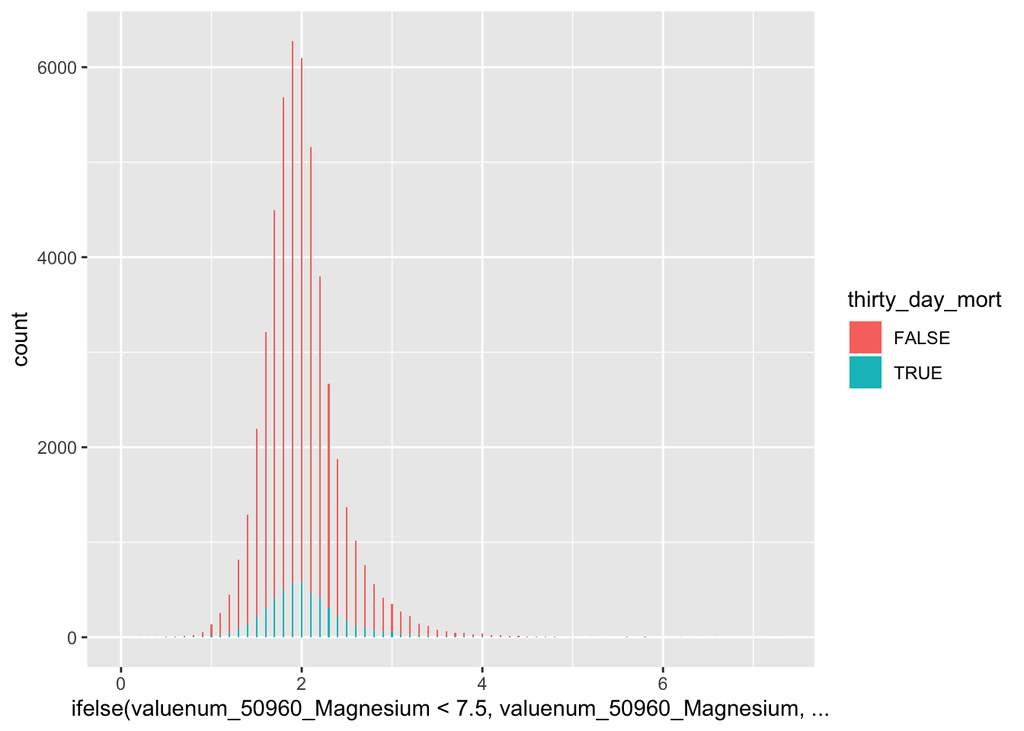

```r
ggplot(data = mimic_icu_cohort) +
  geom_bar(
    mapping = aes(
      x = ifelse(valuenum_50960_Magnesium < 7.5,
                 valuenum_50960_Magnesium, NA),
      fill = thirty_day_mort))
```

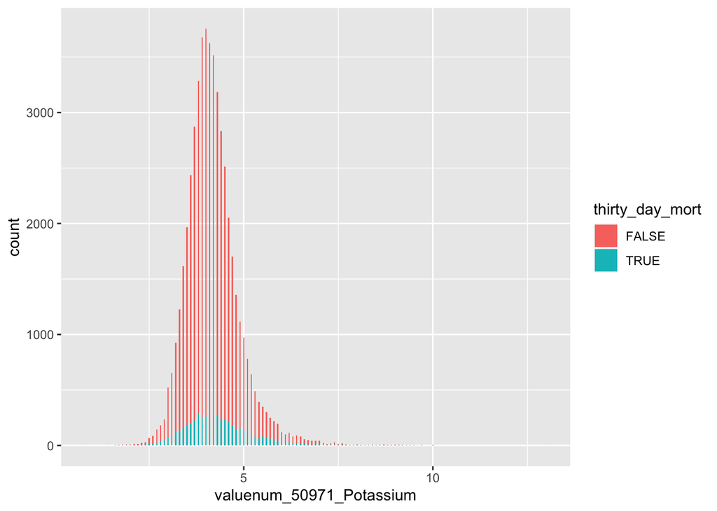

```r
ggplot(data = mimic_icu_cohort) +
  geom_bar(
    mapping = aes(x = valuenum_50971_Potassium, fill = thirty_day_mort))
```

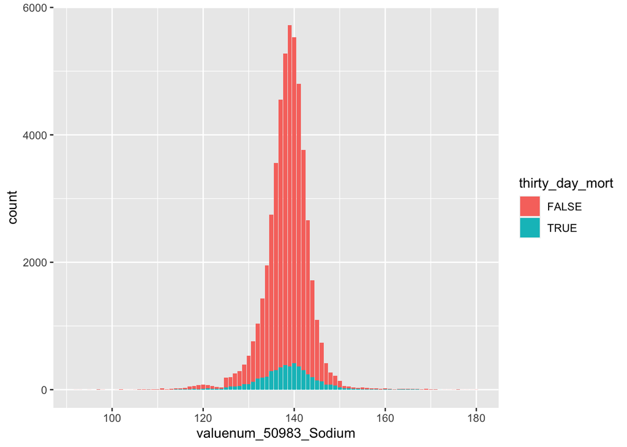

```r
ggplot(data = mimic_icu_cohort) +
  geom_bar(
    mapping = aes(x = valuenum_50983_Sodium, fill = thirty_day_mort))
```

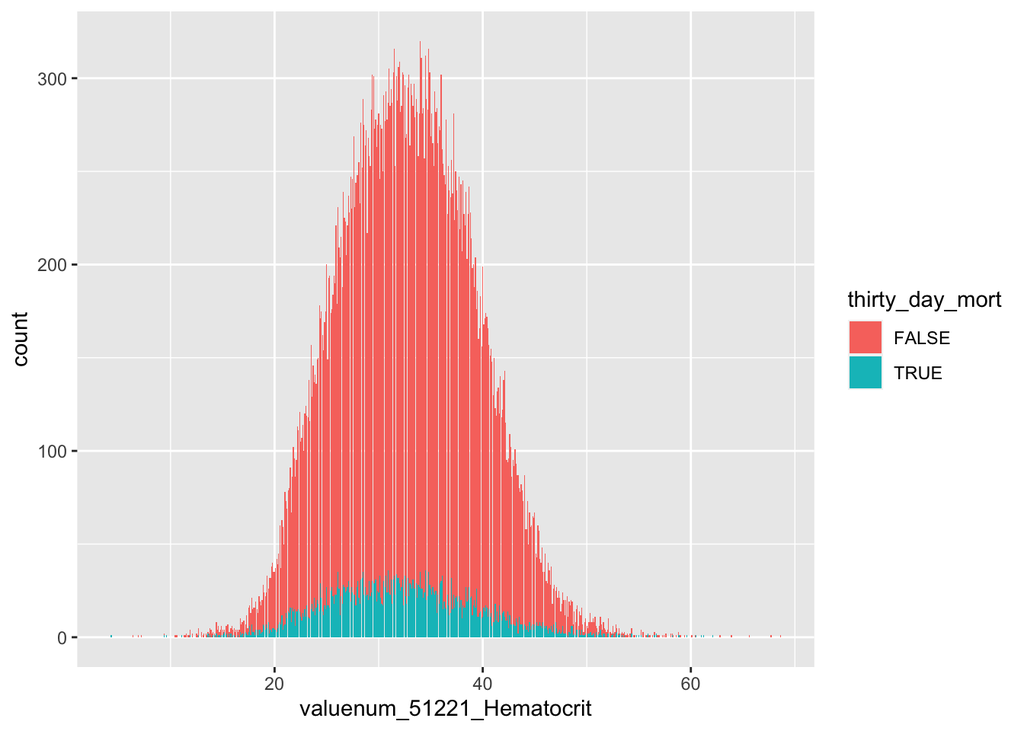

```r
ggplot(data = mimic_icu_cohort) +
  geom_bar(
    mapping = aes(x = valuenum_51221_Hematocrit, fill = thirty_day_mort))
```

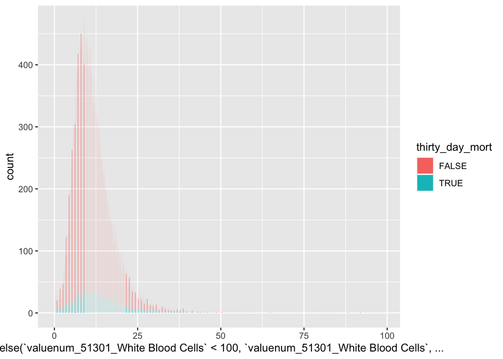

```r
ggplot(data = mimic_icu_cohort) +
  geom_bar(
    mapping = aes(
      x = ifelse(`valuenum_51301_White Blood Cells` < 100,
                 `valuenum_51301_White Blood Cells`, NA),
      fill = thirty_day_mort))
```

- `thirty_day_mort` vs first vital measurements

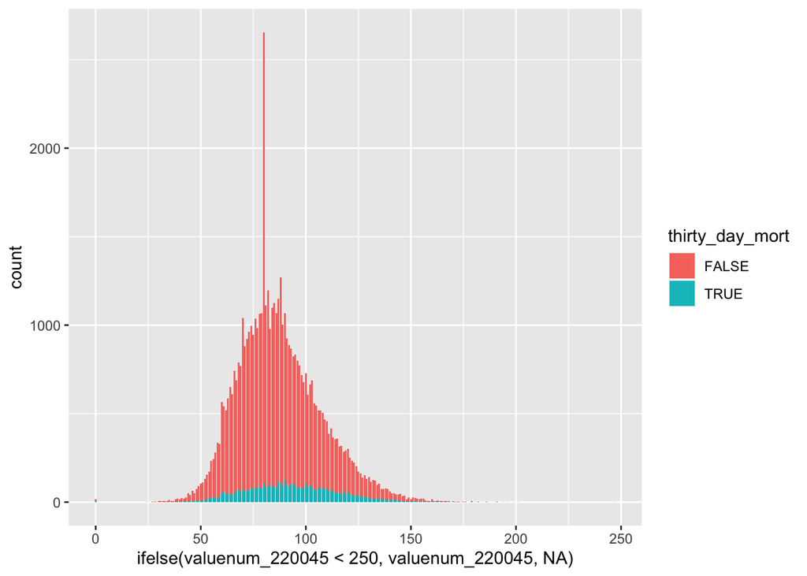

```r
ggplot(data = mimic_icu_cohort) +
  geom_bar(mapping = aes(
    x = ifelse(valuenum_220045 < 250, valuenum_220045, NA),
    fill = thirty_day_mort))
```

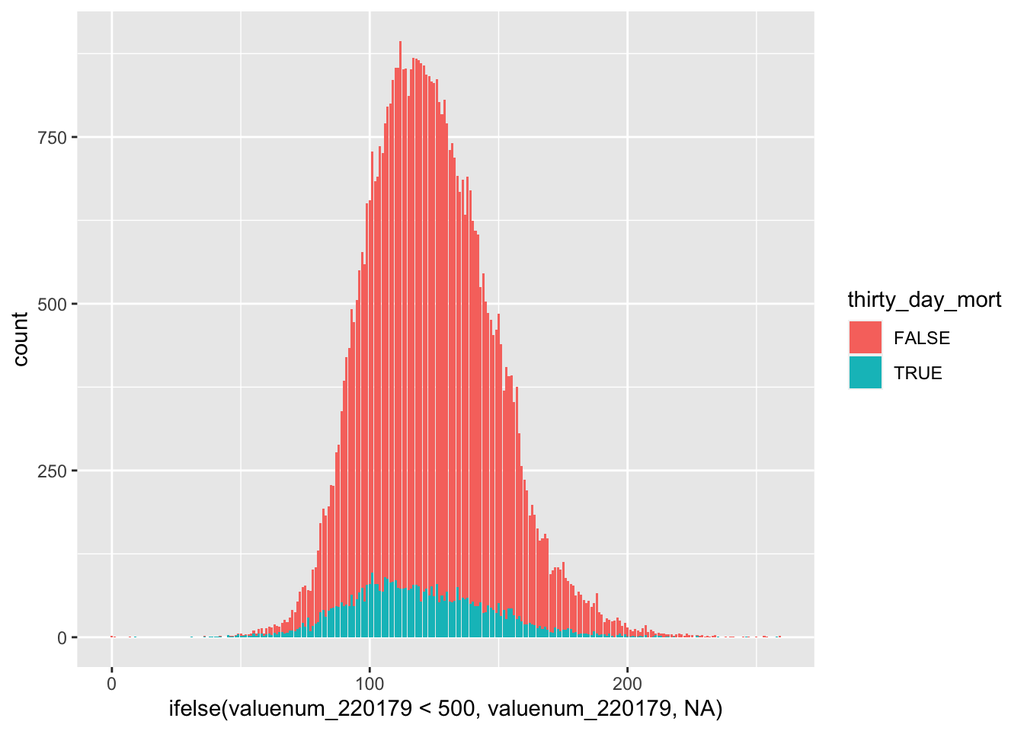

```r
ggplot(data = mimic_icu_cohort) +
  geom_bar(mapping = aes(
    x = ifelse(valuenum_220179 < 500, valuenum_220179, NA),
    fill = thirty_day_mort))
```

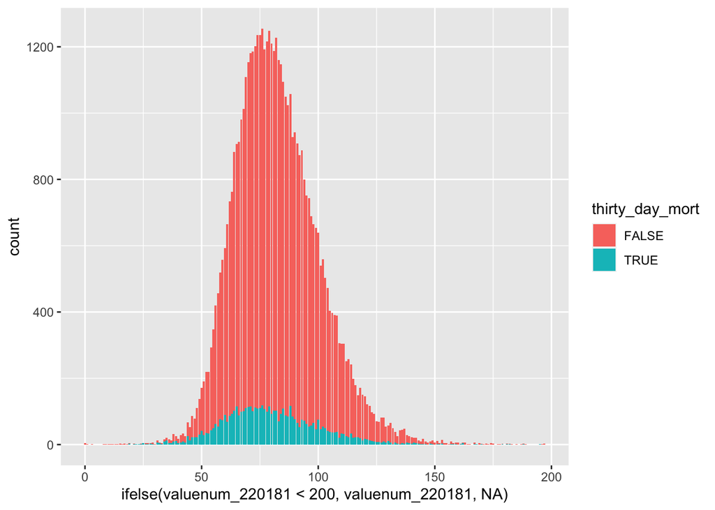

```r
ggplot(data = mimic_icu_cohort) +
  geom_bar(mapping = aes(
    x = ifelse(valuenum_220181 < 200, valuenum_220181, NA),
    fill = thirty_day_mort))
```

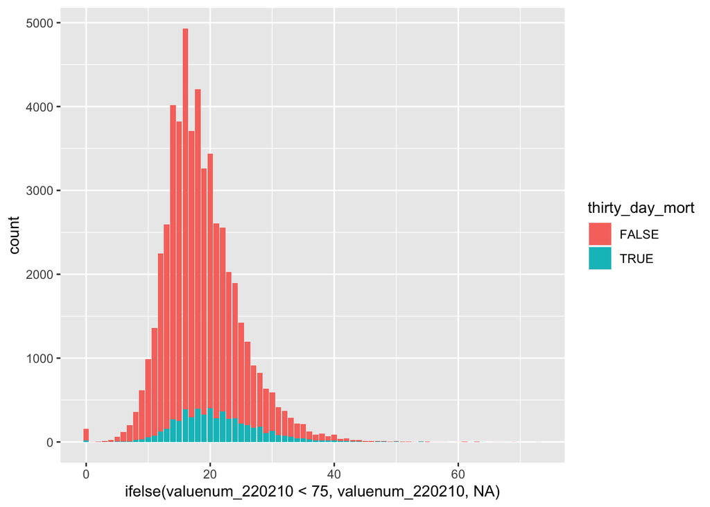

```r
ggplot(data = mimic_icu_cohort) +
  geom_bar(mapping = aes(
    x = ifelse(valuenum_220210 < 75, valuenum_220210, NA),
    fill = thirty_day_mort))
```

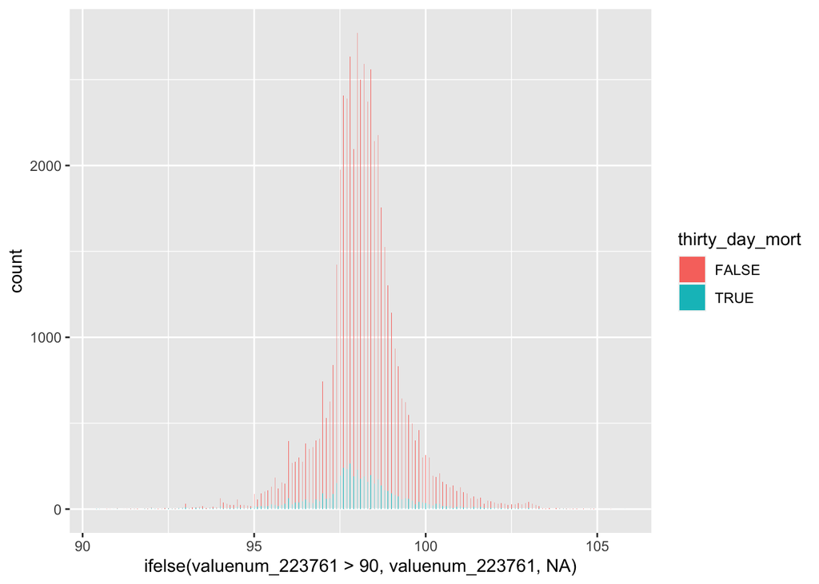

```r
ggplot(data = mimic_icu_cohort) +
  geom_bar(mapping = aes(
    x = ifelse(valuenum_223761 > 90, valuenum_223761, NA),
    fill = thirty_day_mort))
```

- `thirty_day_mort` vs first ICU unit

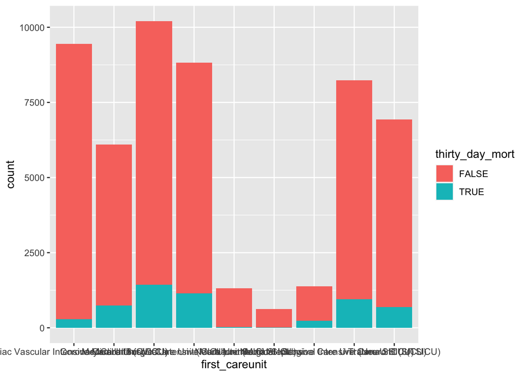

```r
ggplot(data = mimic_icu_cohort) +
  geom_bar(mapping = aes(x = first_careunit, fill = thirty_day_mort))
```

```r
rm(list = ls())
gc()
```

```
##           used (Mb) gc trigger  (Mb) limit (Mb)  max used   (Mb)
## Ncells 1243458 66.5    2160392 115.4         NA   2160392  115.4
## Vcells 5299493 40.5   78186886 596.6      32768 152688923 1165.0
```